# ManyClasses 1 Simulated Analysis

```r
library(runjags)
library(tidyr)
library(dplyr)
library(ggplot2)
library(ggstance)
library(stringr)
library(tibble)
library(forcats)
library(purrr)
library(tidybayes)
```

Set seed for reproducibility

```r
set.seed(47401)
```

# Generating Fake Data

To simulate the analysis, we generate data that has the same structure as the eventual ManyClasses 1 data. These are the parameters of that data generating process.

```r
n.classes <- 42
```

Generate a data frame of classes with random values for each factor. Note that not all moderators are included here, but we do include all *kinds* of moderators. The analysis script generalizes to a dataset that contains additional/different moderators. This is purely a convenience for the simulated data.

```r
classes <- data.frame(
  class.id=1:n.classes,
  incentive=factor(sample(c("Incentivized", "Non-incentivized"), n.classes, replace=T), levels=c("Non-incentivized", "Incentivized")),
  discipline=factor(sample(c("STEM", "Non-STEM"), n.classes, replace=T), levels=c("Non-STEM", "STEM")),
  format=factor(sample(c("Classroom", "Online", "Hybrid"), n.classes, replace=T), levels=c("Classroom", "Hybrid", "Online")),
  class.size=rbinom(n.classes, 150, 0.5),
  proportion.lecture=rbeta(n.classes, 0.8, 0.8),
  n.assignments=2+rbinom(n.classes, 10, 0.1),
  class.level=factor(sample(c("Intro","Intermediate","Advanced"), n.classes, replace=T), levels=c("Intro", "Intermediate", "Advanced")),
  n.exams=2+sample(c(0,2),n.classes, prob = c(0.8, 0.2), replace=T),
  admission.rate=rbeta(n.classes,3,2),
  assignment.difficulty=round(runif(n.classes, 75, 95), 2),
  feedback.type=factor(sample(c("Verification", "Correct Answer", "Explanation"), n.classes, replace=T), levels=c("Verification", "Correct Answer", "Explanation"))
)
```

We generate students that come from each class, create exams, assign random scores to the exams, and normalize the data. To norm the data we z-score each exam separately, and then find the average difference in z-scores for delayed and immediate feedback. We build in a pretty strong effect of individual student performance, assuming that students who do well in general will continue to do well regardless of feedback type, but that feedback may modulate this a bit.

```r
student.data <- NA
for(c in 1:n.classes){
  class.size <- classes$class.size[c]
  student.id <- 1:class.size
  exam <- 1:(classes$n.exams[c])
  one.class <- expand.grid(student.id=student.id, exam=exam) %>%
    left_join(data.frame(student.id=student.id, overall.performance=rnorm(class.size,0,1)), by="student.id") %>%
    mutate(immediate.feedback = if_else(student.id <= class.size/2, exam %% 2 == 1, exam %% 2 == 0)) %>%
    mutate(feedback = if_else(immediate.feedback, "Immediate", "Delayed")) %>%
    select(-immediate.feedback) %>%
    mutate(exam.score = overall.performance + rnorm(n(),0,0.2)) %>%
    group_by(exam) %>%
    mutate(m = mean(exam.score), sd = sd(exam.score), exam.score.normed = (exam.score - mean(exam.score)) / sd(exam.score)) %>%
    ungroup() %>%
    group_by(student.id, feedback) %>%
    summarize(average.z = mean(exam.score.normed)) %>%
    spread(feedback, average.z) %>%
    mutate(delta.z = Immediate - Delayed) %>%
    mutate(class.id = c)
  if(c > 1){
    student.data <- rbind(student.data, one.class)
  } else {
    student.data <- one.class
  }
}
```

Generating moderator variables for students. Like the classes data, this is not necessarily an exhaustive set of moderators.

```r
student.data <- student.data %>% mutate(
  access.all.assignments = factor(sample(c("No", "Yes"), n(), replace=T, prob=c(0.1, 0.9)), levels=c("No", "Yes")),
  access.all.delayed.feedback = factor(sample(c("No", "Yes"), n(), replace=T, prob=c(0.2, 0.8)), levels=c("No", "Yes")),
  cumulative.assignment.time = rgamma(n(), 10),
  cumulative.feedback.time = rgamma(n(),10),
  cumulative.canvas.grade = rnorm(n(), 0, 1), # normalized
  submission.days.early = runif(n(),0,5),
  feedback.delay = runif(n(),1,10)
)
```

Join the class moderators to the student data.

```r
student.class.data <- student.data %>%
  left_join(classes, by="class.id")
```

Add effects to the data.

```r
characteristic.noise <- sd(student.class.data$delta.z)
# overall effect of feedback
student.class.data <- student.class.data %>%
  mutate(delta.z = delta.z + rnorm(n(),0.2*characteristic.noise, characteristic.noise))
# classroom-level discrete moderator
student.class.data <- student.class.data %>%
  mutate(delta.z = case_when(
    feedback.type=="Verification" ~ delta.z + rnorm(n(), 0.15*characteristic.noise, characteristic.noise),
    feedback.type=="Correct Answer" ~ delta.z + rnorm(n(), 0, characteristic.noise),
    feedback.type=="Explanation" ~ delta.z + rnorm(n(), -0.15*characteristic.noise, characteristic.noise)
  ))
# classroom-level continuous moderator
student.class.data <- student.class.data %>%
  mutate(delta.z = delta.z + 0.02*(assignment.difficulty - 85) + rnorm(n(), 0, characteristic.noise))
# student-level continuous moderator
student.class.data <- student.class.data %>%
  mutate(delta.z = delta.z + (-0.25*characteristic.noise) * cumulative.canvas.grade + rnorm(n(), 0, characteristic.noise))
# student-level discrete moderator
student.class.data <- student.class.data %>%
  mutate(delta.z = case_when(
    access.all.delayed.feedback == "No" ~ delta.z + rnorm(n(), 0.8*characteristic.noise, characteristic.noise),
    access.all.delayed.feedback == "Yes" ~ delta.z
  ))
```

When the real data are collected, the analysis script will load the data here.

# Preparing Data for Model

The data needs to be packaged for the JAGS model.

```r
# summaries for JAGS
delta.z <- student.class.data$delta.z
n.students <- nrow(student.class.data)
class.index <- student.class.data$class.id
class.condition <- as.numeric(classes$incentive)
n.conditions <- 2
# packaging data for JAGS
jags.data <- list(
  delta.z=delta.z,
  n.students=n.students,
  class.index=class.index,
  class.condition=class.condition,
  n.conditions=n.conditions,
  n.classes=n.classes
)
```

# Model 1: Overall Effect of Feedback and Incentives

This model estimates the distribution of delta-z scores in each classroom, as well as the distribution of classroom averages in each incentive condition. The JAGS model code is available in `basic-model-jags.txt`.

```r
# set some runjags options to make it more compatible with notebook output
runjags.options(force.summary=TRUE, silent.jags=TRUE, silent.runjags=TRUE)
```

## Running the Model

We use a relatively small sample for the MCMC chains here. We will scale this as needed for the actual data (see `model-diagnostic-plan.md`).

```r
model.1.result <- run.jags(
  model='basic-model-jags.txt',
  data=jags.data,
  n.chains = 3,
  sample = 1000,
  burnin = 1000,
  monitor = c('mu.class','sigma.class', 'mu.condition.effect', 'sigma.condition.effect', 'sigma.mode', 'sigma.sd', 'mu.condition.diff', 'mu.condition.average')
)
```

## Class-level effect of feedback and incentive

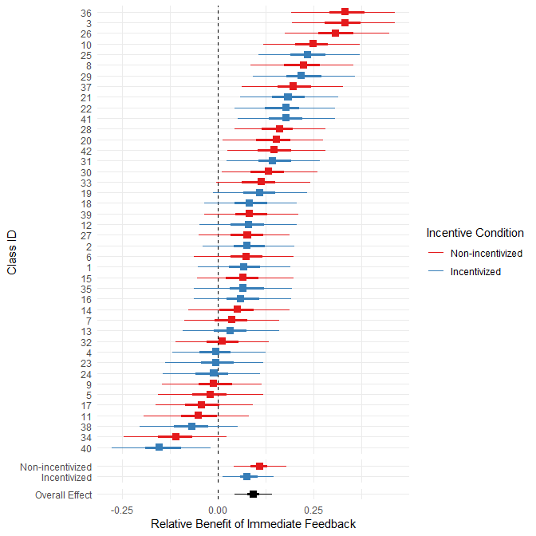

```r
tidy.model.1.summary <- model.1.result %>%
  gather_draws(mu.class[class.id], mu.condition.effect[incentive], mu.condition.average) %>%
  median_hdci(.width = c(0.5,0.95)) %>%
  left_join(classes, by=c("class.id")) %>%
  mutate(incentive.y = as.character(incentive.y)) %>%
  mutate(incentive = case_when(
    .variable == "mu.condition.average" ~ "z",
    incentive.x == 1 ~ "Non-incentivized",
    incentive.x == 2 ~ "Incentivized",
    is.na(incentive.x) ~ incentive.y
  )) %>%
  select(-incentive.x, -incentive.y) %>%
  mutate(y.label = case_when(
    .variable == 'mu.condition.average' ~ "Overall Effect",
    is.na(class.id) ~ incentive,
    !is.na(class.id) ~ as.character(class.id)
  )) %>%
  ungroup() %>%
  mutate(.variable = factor(.variable, levels=c('mu.class', 'mu.condition.effect', 'mu.condition.average'))) %>%
  mutate(y.label = factor(y.label)) %>%
  mutate(y.label = fct_reorder(y.label, .value))

ggplot(tidy.model.1.summary, aes(x=.value, y=y.label, xmin=.lower, xmax=.upper, color=incentive))+
  geom_vline(xintercept=0, linetype='dashed') +
  geom_pointintervalh(shape=15) +
  labs(y="Class ID", x="Relative Benefit of Immediate Feedback")+
  facet_grid(.variable~., scales = 'free', space='free')+
  scale_color_manual(name="Incentive Condition", breaks=c("Non-incentivized", "Incentivized"), labels=c("Non-incentivized", "Incentivized", NULL), values=c("#377eb8", "#e41a1c", "Black"))+
  theme_minimal()+
  theme(strip.background = element_blank(), strip.text = element_blank())
```

Summary stats on difference between Incentive and No Incentive estimated by model.

```r
model.1.result %>%
  gather_draws(mu.condition.diff, mu.condition.average) %>%
  median_hdci(.width = c(0.95))
```

| .variable | .value | .lower | .upper | .width | .point | .interval |
| --- | --- | --- | --- | --- | --- | --- |
| mu.condition.average | 0.09385298 | 0.04371346 | 0.1412145 | 0.95 | median | hdci |
| mu.condition.diff | 0.03297005 | -0.07068938 | 0.1225135 | 0.95 | median | hdci |

Quick plot of Means and SEs without model estimation, to illustrate degree of shrinkage. Not intended for inclusion in the manuscript.

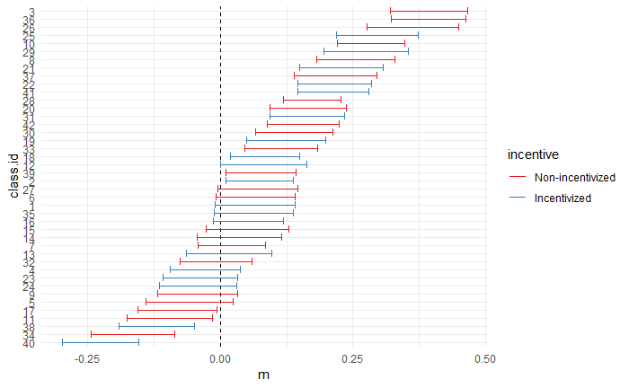

```r
student.class.data %>%
  group_by(class.id) %>%
  summarise(m = mean(delta.z), se=sd(delta.z)/sqrt(n())) %>%
  left_join(classes, by="class.id") %>%
  mutate(class.id = factor(class.id)) %>%
  mutate(class.id = fct_reorder(class.id, m)) %>%
  ggplot(aes(x=m, xmin=m-se, xmax = m+se, y=class.id, color=incentive)) +
  geom_vline(xintercept=0, linetype='dashed') +
  geom_errorbarh()+
  scale_color_brewer(type="qual", palette = "Set1")+
  theme_minimal()
```

# Heterogeneity Analysis

We quantify heterogeneity at the classroom level by looking at the model’s estimate of the standard deviation of classroom-level means.

```r
model.1.h.tidy <- model.1.result %>% gather_draws(sigma.condition.effect[incentive])
model.1.h.tidy %>% median_hdci(.width = c(0.95))
```

| incentive | .variable | .value | .lower | .upper | .width | .point | .interval |
| --- | --- | --- | --- | --- | --- | --- | --- |
| 1 | sigma.condition.effect | 0.1452480 | 0.09682531 | 0.2097749 | 0.95 | median | hdci |
| 2 | sigma.condition.effect | 0.1263261 | 0.06783087 | 0.1863532 | 0.95 | median | hdci |

We can visualize the distribution of classroom-level means according to the model.

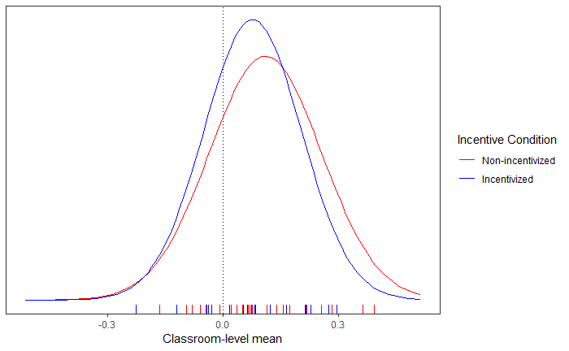

```r
class.means <- student.class.data %>% group_by(class.id) %>% summarize(M=mean(delta.z)) %>% pull(M)
condition.summary <- model.1.result %>%
  spread_draws(mu.condition.effect[incentive], sigma.condition.effect[incentive]) %>%
  median_hdci(.width=c(0.95))
ggplot(data.frame(x=c(-sd(class.means)*3.5,sd(class.means)*3.5)),aes(x, color=g))+
  stat_function(data=data.frame(x=c(-sd(class.means)*3.5,sd(class.means)*3.5), g=factor(1)), geom="line", fun=dnorm, n=101, args=list(
    mean = (condition.summary %>% filter(incentive==1) %>% pull(mu.condition.effect)),
    sd = (condition.summary %>% filter(incentive==1) %>% pull(sigma.condition.effect)))) +
  stat_function(data=data.frame(x=c(-sd(class.means)*3.5,sd(class.means)*3.5), g=factor(2)),geom="line",fun=dnorm, n=101, args=list(
    mean = (condition.summary %>% filter(incentive==2) %>% pull(mu.condition.effect)),
    sd = (condition.summary %>% filter(incentive==2) %>% pull(sigma.condition.effect)))) +
  #geom_dotplot(data=(student.class.data %>% group_by(class.id, incentive) %>% summarize(M=mean(delta.z)) %>% filter(!is.nan(M)) %>% mutate(incentive=factor(as.numeric(incentive)))), aes(x=M, color=incentive, fill=incentive), binwidth=0.1, size=1, alpha= 0.3) +
   geom_rug(data=(student.class.data %>% group_by(class.id, incentive) %>% summarize(M=mean(delta.z)) %>% filter(!is.nan(M)) %>% mutate(incentive=factor(as.numeric(incentive)))), aes(x=M, color=incentive, fill=incentive)) +
  scale_y_continuous(breaks=NULL)+
  geom_vline(xintercept = 0, color="black", linetype="dotted")+
  scale_color_manual(name="Incentive Condition", values=c('red', 'blue'), labels=c("Non-incentivized", "Incentivized"))+
  scale_fill_manual(name="Incentive Condition", values=c('red', 'blue'), labels=c("Non-incentivized", "Incentivized"))+
  theme_bw()+
  labs(x="Classroom-level mean", y=NULL)+
  theme(panel.grid = element_blank())
```

# Moderator Analysis

## Class Level

Create a function to pick the correct model depending on the moderator type and pass in the correct data values.

```r
estimate.class.moderator.effect <- function(moderator.name, summarize=TRUE){

  #print(moderator.name)

  if(!moderator.name %in% colnames(classes)) {
    stop(paste0("Moderator '", moderator.name, "' does not appear in classes data frame"))
  }

  # packaging data for JAGS
  jags.data.moderator <- list(
    delta.z=delta.z,
    n.students=n.students,
    class.index=class.index,
    class.condition=class.condition,
    n.conditions=n.conditions,
    n.classes=n.classes,
    moderator.level = as.numeric(classes[[moderator.name]]),
    no.incentive.classes = which(class.condition==1),
    incentive.classes = which(class.condition==2)
  )

  if(is.numeric(classes[[moderator.name]])){
    model <- 'cont-class-moderator-model-jags.txt'
  } else {
    model <- 'disc-class-moderator-model-jags.txt'
    jags.data.moderator$n.moderator.levels = length(levels(classes[[moderator.name]]))
  }

  model.moderator.result <- run.jags(
    model=model,
    data=jags.data.moderator,
    n.chains = 3,
    sample = 3000,
    burnin = 1000,
    monitor = c('mu.class','sigma.class', 'mu.condition.effect', 'sigma.condition.effect', 'sigma.mode', 'sigma.sd', 'moderator.effect', 'r.sq')
  )

  if(summarize){
    df <- model.moderator.result %>%
      gather_draws(r.sq[incentive], sigma.condition.effect[incentive]) %>%
      median_hdci(.value, .width=c(0.5,0.95)) %>%
      mutate(moderator = moderator.name)

    return(df)
  } else {
    return(model.moderator.result)
  }
}
```

Iterate through moderators and run the corresponding models.

```r
class.level.moderators <- colnames(classes)[3:length(colnames(classes))]
class.moderator.estimates <- NA
for(m in class.level.moderators){
  md <- estimate.class.moderator.effect(m)
  if(is.na(class.moderator.estimates)){
    class.moderator.estimates <- md
  } else {
    class.moderator.estimates <- rbind(class.moderator.estimates, md)
  }
}
```

Plot the R^2 of the models with class-level moderators

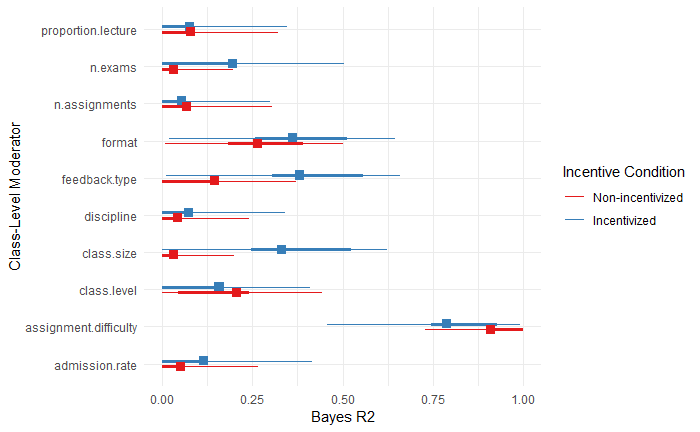

## Student Level

```r
estimate.student.moderator.effect <- function(moderator.name, summarize=TRUE){

  #print(moderator.name)

  if(!moderator.name %in% colnames(student.class.data)) {
    stop(paste0("Moderator '", moderator.name, "' does not appear in student.class.data data frame"))
  }

  # packaging data for JAGS
  jags.data.moderator <- list(
    delta.z=delta.z,
    n.students=n.students,
    class.index=class.index,
    class.condition=class.condition,
    n.conditions=n.conditions,
    n.classes=n.classes,
    moderator.level = as.numeric(student.class.data[[moderator.name]]),
    no.incentive.classes = which(class.condition==1),
    incentive.classes = which(class.condition==2)
  )

  monitor.list <- c('mu.class','sigma.class', 'mu.condition.effect', 'sigma.condition.effect', 'sigma.mode', 'sigma.sd', 'moderator.effect', 'moderator.effect.class', 'moderator.effect.sigma', 'r.sq')

  if(is.numeric(student.class.data[[moderator.name]])){
    model <- 'cont-student-moderator-model-jags.txt'
  } else {
    model <- 'disc-student-moderator-model-jags.txt'
    jags.data.moderator$n.moderator.levels = length(levels(student.class.data[[moderator.name]]))
  }

  model.moderator.result <- run.jags(
    model=model,
    data=jags.data.moderator,
    n.chains = 3,
    sample = 3000,
    burnin = 1000,
    monitor = monitor.list
  )

  if(summarize){
    df <- model.moderator.result %>%
      gather_draws(r.sq[incentive], sigma.condition.effect[incentive]) %>%
      median_hdci(.value, .width=c(0.5,0.95)) %>%
      mutate(moderator = moderator.name)

    return(df)
  } else {
    return(model.moderator.result)
  }
}
```

Iterate through the student-level moderators and run the corresponding moderator model.

```r
student.level.moderators <- colnames(student.data)[6:length(colnames(student.data))]
student.moderator.estimates <- NA
for(m in student.level.moderators){
  md <- estimate.student.moderator.effect(m)
  if(is.na(student.moderator.estimates)){
    student.moderator.estimates <- md
  } else {
    student.moderator.estimates <- rbind(student.moderator.estimates, md)
  }
}
```

Plot student-level moderators

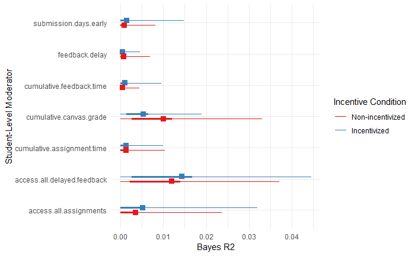

# Plotting individual moderators

These figures are examples of the kinds of moderator figures that we might generate. The specific moderators that we visualize in the manuscript will depend on the results of the above analysis. The code below is mostly generic and can run on any moderator, minus a few visual details that need to be tweaked by hand like axis labels.

## Classroom-level

### Continuous

```r
moderator.name <- 'assignment.difficulty'
moderator.pretty.name <- 'Average Assignment Difficulty'
moderator.model.results <- estimate.class.moderator.effect(moderator.name, summarize=FALSE)
model.class.estimates <- moderator.model.results %>%
  gather_draws(mu.class[class.id]) %>%
  median_hdci(.width = c(0.5, 0.95)) %>%
  left_join(classes, by="class.id")
model.moderator.estimates <- moderator.model.results %>%
  spread_draws(mu.condition.effect[incentive], moderator.effect[incentive]) %>%
  mutate(slope = moderator.effect / sd(classes[[moderator.name]])) %>%
  mutate(intercept = mu.condition.effect - moderator.effect * mean(classes[[moderator.name]])/sd(classes[[moderator.name]])) %>%
  ungroup() %>%
  mutate(incentive = factor(incentive, labels=c("Non-incentivized", "Incentivized"))) %>%
  group_by(incentive) %>%
  sample_n(20)
moderator.model.results %>%
  spread_draws(mu.condition.effect[incentive], moderator.effect[incentive]) %>%
  mutate(slope = moderator.effect / sd(classes[[moderator.name]])) %>%
  #mutate(intercept = mu.condition.effect - moderator.effect * mean(classes[[moderator.name]])/sd(classes[[moderator.name]])) %>%
  median_hdci(slope, .width=c(0.5,0.95))
```

| incentive | slope | .lower | .upper | .width | .point | .interval |
| --- | --- | --- | --- | --- | --- | --- |
| 1 | 0.02206352 | 0.02012283 | 0.02421563 | 0.50 | median | hdci |
| 2 | 0.01717358 | 0.01448438 | 0.01924051 | 0.50 | median | hdci |
| 1 | 0.02206352 | 0.01583389 | 0.02801366 | 0.95 | median | hdci |
| 2 | 0.01717358 | 0.01021944 | 0.02492102 | 0.95 | median | hdci |

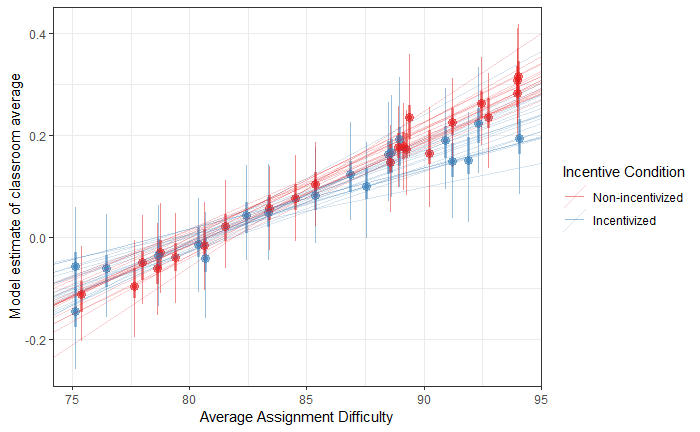

```r
ggplot(model.class.estimates, aes(x=assignment.difficulty, y=.value, ymin=.lower, ymax=.upper, color=incentive)) +
  geom_pointinterval(alpha=0.5) +
  geom_abline(data=model.moderator.estimates, aes(intercept = intercept, slope=slope, color=factor(incentive)), alpha=0.2) +
  labs(x=moderator.pretty.name, y="Model estimate of classroom average")+
  scale_color_brewer(type="qual", palette = "Set1", name="Incentive Condition")+
  theme_bw()
```

### Discrete

```r
moderator.name <- 'class.level'
moderator.model.results <- estimate.class.moderator.effect(moderator.name, summarize=FALSE)
```

```
No initial values were provided - JAGS will use the same initial values for all chains
```

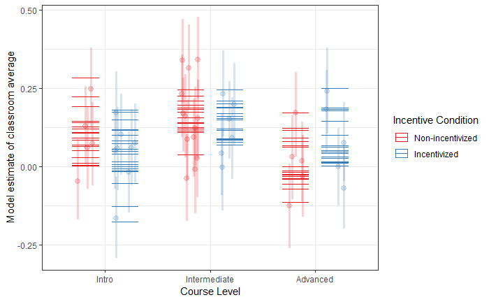

```r
model.class.estimates <- moderator.model.results %>%
  gather_draws(mu.class[class.id]) %>%
  median_hdci(.width = c(0.95)) %>%
  left_join(classes, by="class.id")
model.moderator.estimates <- moderator.model.results %>%
  spread_draws(mu.condition.effect[incentive], moderator.effect[incentive, moderator.level]) %>%
  ungroup() %>%
  mutate(incentive = factor(incentive, labels=c("Non-incentivized", "Incentivized"))) %>%
  mutate(class.level = factor(moderator.level, labels=c("Intro", "Intermediate", "Advanced"))) %>%
  group_by(incentive, class.level) %>%
  sample_n(20)

ggplot(model.class.estimates, aes(x=class.level, y=.value, ymin=.lower, ymax=.upper, color=incentive)) +
  geom_pointinterval(position=position_jitterdodge(), alpha=0.2) +
  geom_crossbar(data=model.moderator.estimates, aes(x=class.level, y = mu.condition.effect + moderator.effect, color=incentive, ymin=..y.., ymax=..y..), position=position_dodge(width=0.75), width=0.5, size=0.1) +
  labs(x="Course Level", y="Model estimate of classroom average")+
  scale_color_brewer(type="qual", palette = "Set1", name="Incentive Condition")+
  theme_bw()
```

## Student-level

### Continuous

```r
student.moderator.name <- 'cumulative.canvas.grade'
student.moderator.model.results <- estimate.student.moderator.effect(student.moderator.name, summarize=FALSE)
student.model.moderator.estimates <- student.moderator.model.results %>%
  spread_draws(mu.class[class.id], moderator.effect.class[class.id]) %>%
  group_by(class.id) %>%
  sample_n(20) %>%
  mutate(slope = moderator.effect.class / sd(student.class.data[[student.moderator.name]])) %>%
  mutate(intercept = mu.class - moderator.effect.class * mean(student.class.data[[student.moderator.name]])/sd(student.class.data[[student.moderator.name]])) %>%
  ungroup() %>%
  left_join(select(classes, class.id, incentive), by="class.id")
student.moderator.model.results %>%
  spread_draws(mu.class[class.id], moderator.effect[incentive]) %>%
  mutate(slope = moderator.effect / sd(student.class.data[[student.moderator.name]])) %>%
  median_hdci(slope, .width=0.95)
```

| class.id | incentive | slope | .lower | .upper | .width | .point | .interval |
| --- | --- | --- | --- | --- | --- | --- | --- |
| 1 | 1 | -0.06995983 | -0.11095931 | -0.03521798 | 0.95 | median | hdci |
| 1 | 2 | -0.06327486 | -0.09679938 | -0.02877304 | 0.95 | median | hdci |
| 2 | 1 | -0.06995983 | -0.11095931 | -0.03521798 | 0.95 | median | hdci |
| 2 | 2 | -0.06327486 | -0.09679938 | -0.02877304 | 0.95 | median | hdci |
| 3 | 1 | -0.06995983 | -0.11095931 | -0.03521798 | 0.95 | median | hdci |
| 3 | 2 | -0.06327486 | -0.09679938 | -0.02877304 | 0.95 | median | hdci |
| 4 | 1 | -0.06995983 | -0.11095931 | -0.03521798 | 0.95 | median | hdci |
| 4 | 2 | -0.06327486 | -0.09679938 | -0.02877304 | 0.95 | median | hdci |
| 5 | 1 | -0.06995983 | -0.11095931 | -0.03521798 | 0.95 | median | hdci |
| 5 | 2 | -0.06327486 | -0.09679938 | -0.02877304 | 0.95 | median | hdci |

[output cut: 74 more lines]

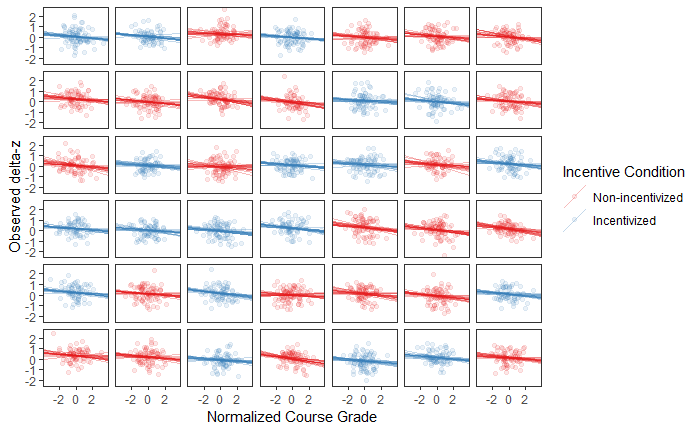

```r
ggplot(student.class.data, aes(x=cumulative.canvas.grade, y=delta.z, color=incentive))+
  facet_wrap(.~class.id)+
  scale_color_brewer(type="qual",palette = "Set1", name="Incentive Condition")+
  geom_point(alpha=0.1)+
  geom_abline(data=student.model.moderator.estimates, aes(slope=slope, intercept=intercept, color=incentive), alpha=0.3)+
  #geom_smooth(method="lm", se=FALSE, color="black")+
  labs(x="Normalized Course Grade", y="Observed delta-z")+
  theme_bw()+
  theme(strip.background = element_blank(), strip.text = element_blank(), panel.grid = element_blank())
```

Examining the condition-level estimates of the moderator

```r
student.moderator.model.results %>%
  spread_draws(moderator.effect[incentive]) %>%
  mutate(slope = moderator.effect / sd(student.class.data[[student.moderator.name]])) %>%
  median_hdci(slope, .width=.95)
```

| incentive | slope | .lower | .upper | .width | .point | .interval |
| --- | --- | --- | --- | --- | --- | --- |
| 1 | -0.06995983 | -0.11095931 | -0.03521798 | 0.95 | median | hdci |
| 2 | -0.06327486 | -0.09679938 | -0.02877304 | 0.95 | median | hdci |

### Discrete

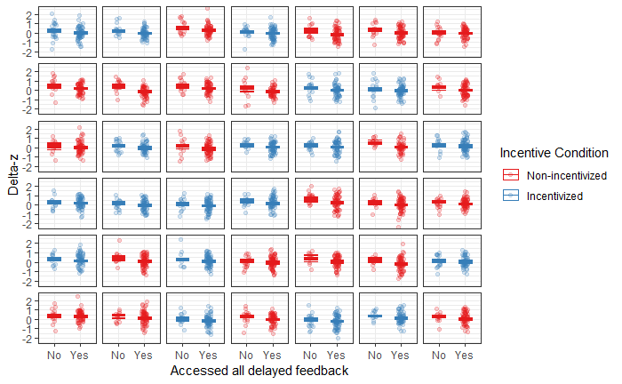

```r
student.moderator.name <- 'access.all.delayed.feedback'
student.moderator.model.results <- estimate.student.moderator.effect(student.moderator.name, summarize=FALSE)
student.model.moderator.estimates <- student.moderator.model.results %>%
  spread_draws(mu.class[class.id], moderator.effect.class[class.id, moderator.level]) %>%
  ungroup() %>%
  mutate(access.all.delayed.feedback = factor(moderator.level, labels=c("No", "Yes"))) %>%
  select(-moderator.level) %>%
  group_by(class.id, access.all.delayed.feedback) %>%
  sample_n(20) %>%
  ungroup() %>%
  left_join(select(classes, class.id, incentive), by="class.id")

ggplot(student.class.data, aes(x=access.all.delayed.feedback, y=delta.z, color=incentive))+
  facet_wrap(.~class.id)+
  geom_point(position=position_jitterdodge(), alpha=0.2) +
  geom_crossbar(data=student.model.moderator.estimates, aes(x=access.all.delayed.feedback, y = mu.class + moderator.effect.class, color=incentive, ymin=..y.., ymax=..y..), position=position_dodge(width=0.75), width=0.5, size=0.1, alpha=0.2) +
  labs(x="Accessed all delayed feedback", y="Delta-z")+
  scale_color_brewer(type="qual", palette = "Set1", name="Incentive Condition")+
  theme_bw()+
  theme(strip.background = element_blank(), strip.text = element_blank())
```

Condition-level moderator estimates

```r
student.moderator.model.results %>%
  spread_draws(moderator.effect[incentive, moderator.level]) %>%
  median_hdci(.width=0.95)
```

| incentive | moderator.level | moderator.effect | .lower | .upper | .width | .point | .interval |
| --- | --- | --- | --- | --- | --- | --- | --- |
| 1 | 1 | 0.14294231 | -0.8819827 | 0.9685201 | 0.95 | median | hdci |
| 1 | 2 | -0.13971966 | -1.1363185 | 0.6774957 | 0.95 | median | hdci |
| 2 | 1 | 0.10958124 | -0.4629117 | 0.4817389 | 0.95 | median | hdci |
| 2 | 2 | -0.06623762 | -0.6453237 | 0.3223643 | 0.95 | median | hdci |